# Working With Pearson’s MyLab Datasets

Yuanting Lu

09/04/2025

### Download Datasets

Follow the steps to download a dataset as an Excel file. Rename the file. For example, if this is the dataset for homework 0202 question 01, you may rename the file as `020201.xlsx`.

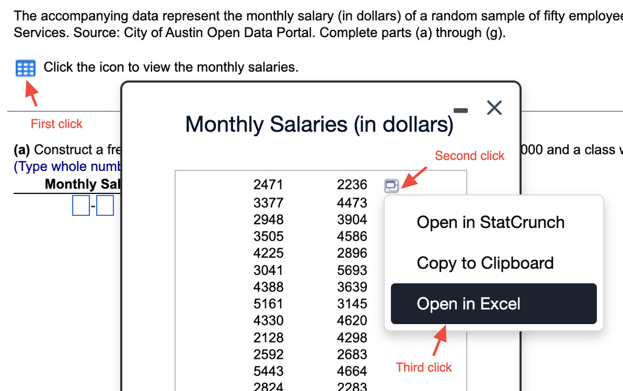

### Convert to .csv File

Open the downloaded file in Excel and save it as .csv file.

[figure not shown]

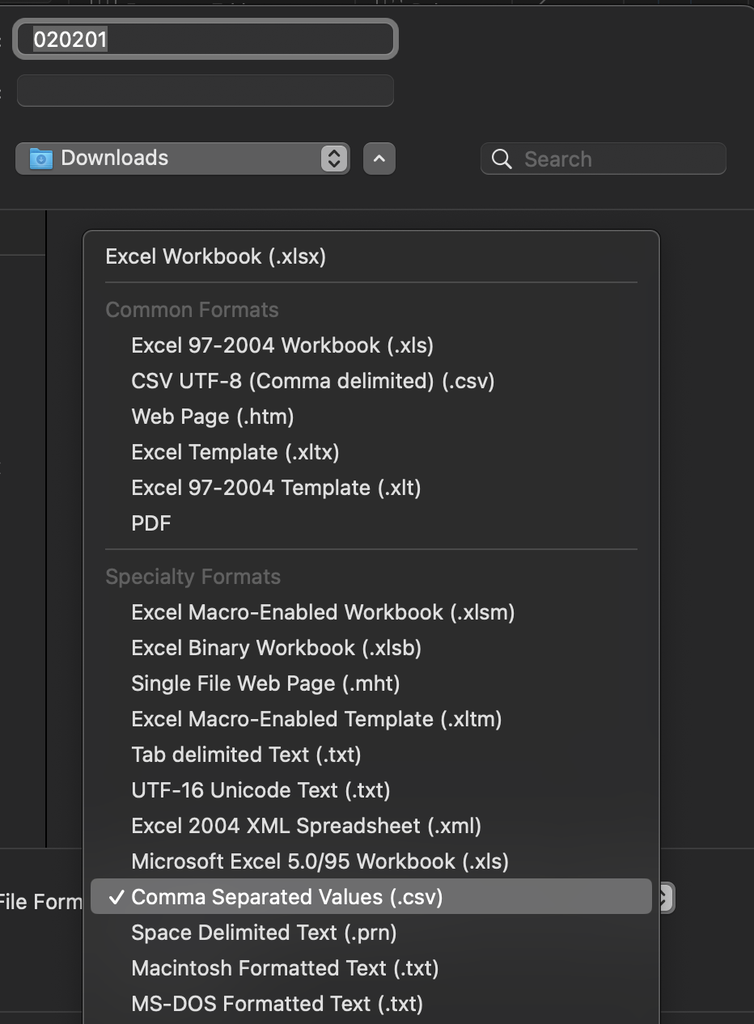

### Load Datasets into R

Use the following commands to load the data. Be sure to (1) replace `your-user-name` with the actual user name on your laptop, (2) replace `020201.csv` by the correct file name.

- Mac version:

  ```r
  df <- read.csv("/Users/your-user-name/Downloads/020201.csv", header = FALSE)
  ```

- Windows version:

  ```r
  df <- read.csv("C:/Users/Your-user-name/Downloads/020201.csv", header = FALSE)
  ```

  - For dataset that has a single variable, provide a meaningful name to the variable, e.g., salary. Then use `df$salary` to access the data.

    ```r
    names(df) <- c("salary")
    df$salary
    ```

  - For dataset that has multiple variables, e.g., ‘Tap’ and ‘Bottled’. After successfully loading the data file into R, use `df$Tap` and `df$Bottled` to access the two variables, respectively.

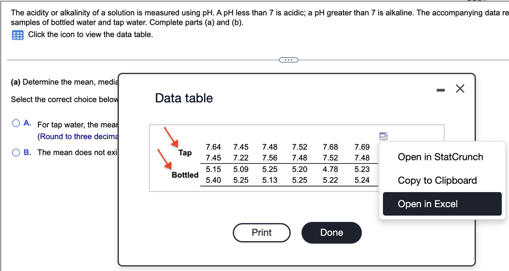

  If we would like to change the variable names, e.g., use ‘t’ for tap water and ‘b’ for bottled water, type `names(df) <- c("t", "b")` and then use `df$t` and `df$b` to access each variable.